# MPP-E1180 Lecture 1: Introduction to the Course

16 September 2016

## Christopher Gandrud

**Contact**:

- Public
  - SyllabusAndLectures/issues
  - [@ChrisGandrud](https://twitter.com/ChrisGandrud)
- Private
  - gandrud@hertie-school.org

**Official Office Hours**:

- Room: 1.64
- Friday: 13:00-14:00 & 17:00-18:00

## Objectives for the topic

- Introduce course motivation, goals, plan, and expectations/assessment
- Introduce collaborative & reproducible data analysis
- Setup computational research environment

## Objectives for the course

**Collaboratively** and **reproducibly**:

1. Gather and clean social data
2. Analyse it to draw informed descriptions/inferences
3. Present results in a variety of mediums

## Objectives for the course

Learn how to actually **do** data analysis using **best practices**

We are going to use **ugly real-world data**, not pristine training data sets.

Use **advanced computational tools** to do **data munging**.

## Motivation: Academic

- Skills needed to do **original quantitative research** for your **thesis**.
  - The final project will be a **trial version** of your thesis.
- State-of-the-art tools needed for **future high-level academic research**.
  - Take advantage of new data sources.
  - Avoid effort duplication.
  - Make your research reproducible.
  - Present your results to multiple forums.

## Motivation: Government

Government agencies are increasingly adopting the technologies and methods of open data science.

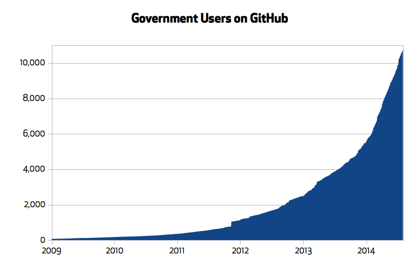

## Motivation: Government

- Public data is increasingly **accessible**.
  - e.g. [World Bank Development Indicators](http://data.worldbank.org/data-catalog/world-development-indicators), [GovData Germany](https://www.govdata.de/neues), [data.gov.uk](http://data.gov.uk/), [New York City](https://nycopendata.socrata.com/), [data.gov](https://www.data.gov/open-gov/)
- Governments rely on data analysis for evidence based decision-making.
  - Tools of open data analysis enable better use of data **within** and **between** government actors.
  - Governments can take advantage of analyses done by **third parties**.

## Motivation: Government

- They are also **sharing** and **collaboratively** developing code; **reducing development costs** and **improving applications**.
- Example: version control to **increase engagement with the legislative process**.
  - [Forkable](https://github.com/SFMOCI/openlaw) San Francisco laws.

## Motivation: NGO

NGO's are becoming increasingly data-oriented and need people with **skills** to **handle and analyse** this data.

Ex. Former MPP-E1180 student Arndt Leininger recently co-founded [CorrelAid](http://correlaid.org/) to assist NGOs with data analysis.

## Motivation: Business

Data analysis and R programming skills in particular are **highly valued** in businesses such as finance and management.

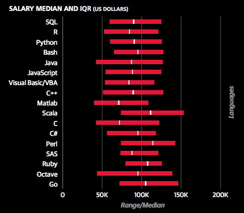

[O'Reilly (2016)](http://www.oreilly.com/data/free/files/2016-data-science-salary-survey.pdf?utm_campaign=Revue%20newsletter&utm_medium=Newsletter&utm_source=revue)

## Why Collaborative?

- Research is collaborative (even if you don't know it).
- Need tools and shared best practices to enable effective collaboration between **explicit research partners**.
- Need tools and shared best practices to enable collaboration between researchers who are **not explicitly** working together often in **unexpected ways**.
  - **Avoids effort duplication**
  - Enables **cumulative knowledge development**
- Tools for collaboration tend to enhance **reproducibility**.

## What is reproducibility?

**Really reproducible** research (Peng 2011, 1226):

> the data and code used to make a finding are **available** and they are **sufficient** for an independent researcher to **recreate the finding**.
- In practice reproducibility is enhanced by **literate programming** where the data, analysis, and presentation of the results are 'weaved' or 'knitted' together.
  - Make available the research, **not just the advertising** for the findings (e.g. papers, book).

## Reproducibility vs. Replication?

**Reproducibility**: an independent study makes the same findings using the **same data** and **code** as the original researchers.

**Replicability**: an independent study makes the same conclusions as the original using **other** data, code, and even methods, i.e. independent verification.

## Reproducibility vs. Replication?

**''A study can be reproducible and still be wrong''** [Peng 2014](http://simplystatistics.org/2014/06/06/the-real-reason-reproducible-research-is-important/).

E.g. a finding that is statistically significant in one study may remain statistically significant when reproduced using the original data/code, but **replication studies are unable to find a similar result**.

The original finding could just have been [noise](http://andrewgelman.com/2014/09/03/disagree-alan-turing-daniel-kahneman-regarding-strength-statistical-evidence/).

## Why reproducibility?

- **Replication** is the ''**ultimate standard**'' for judging scientific claims (Peng 2011).
- **Reproducibility**
  - **Enhances replication** (other researchers can understand how an analysis was actually done)
  - Is a **minimum standard** for judging scientific claims when replication is not possible.

## Why reproducibility?

Reproducibility helps **avoid effort duplication**:

- Others **don't waste time**:
  - Gathering data that has already been gathered.
  - Discovering procedures that have already been discovered.

## Why reproducibility?

- Reproducibility also makes it possible to **find and correct errors**.
- Recent examples:
  - Translation errors in the [World Values Survey](http://www.washingtonpost.com/blogs/monkey-cage/wp/2014/09/02/world-values-lost-in-translation/).
  - Data errors in research on [intestinal worm treatment and school attendance](http://www.columbia.edu/~mh2245/w/worms.html).
  - [L'Affaire LaCour](http://www.vox.com/2015/5/20/8630535/same-sex-marriage-study): data *fabrication* discovered.
- Data errors can cause spurious findings that ultimately **waste researchers time**, because they try to explain 'wrong' findings.

## Why reproducibility?

- **Higher research impact**
  - Reproducible research is likely to be more **useful for other researchers**. They can use your data and learn from your code and methods.
  - More use more impact (e.g. citations)
- **Better work habits**
  - Thinking about reproducibility from the beginning makes your files **better organised** and your work is **better documented**.
  - This allows you to **build on your own work** more effectively.

## Reproducible Workflow

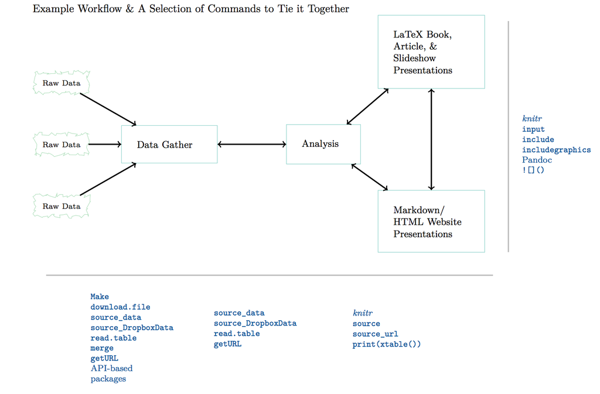

## Example (Truncated) Workflow

This lecture is created using [RMarkdown](http://rmarkdown.rstudio.com/). It allows me to create both PDF and HTML slides.

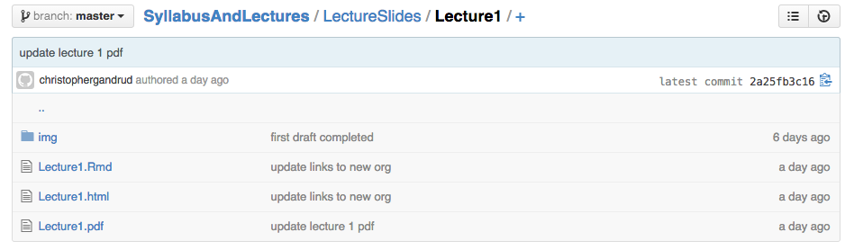

Lecture file structure

## Practical Tips for Reproducible Research

- Document Everything!
- Everything is a (text) file.
- All files should be human readable.
- Explicitly tie your files together.
- Have a plan to organise, store, and make your files available.

## Course Prerequisites

- **Introductory-level statistics**
  - Basic descriptive statistics (e.g. data types, ways of describing distributions)
  - Basic inferential statistics: (significance testing, linear regression)
  - Exposure to statistics software (e.g. SPSS, STATA)
- Knowledge of particular software or computer programming is **not expected**
- **Patience**
  - Work hard so you can be lazy.

## Course Outline (1)

**Part I: Motivation and Getting Started**

- Introduction to the Course
- Introduction to the R Programming Language
- Files, Files Structures, Version Control, and Collaboration

**Part II Markup Languages and Literate Programming**

- Introduction to Markup Languages and Literate Programming (1)
- Introduction to Markup Languages and Literate Programming (2)

## Course Outline (2)

**Part III: Data Gathering, Trasformations, and Analysis**

- Automatic Data Gathering via Curl, API Packages + Cleaning
- Automatic Data Gathering via Web Scraping
- Statistical Modelling with R

**Part IV: Communicating Results from Statistical Analyses**

- Automatic Table Generation and Static Visualisation
- Dynamic Visualisation

**Part V: Collaborative Research Project**

## Typical Two Hour Topic Plan

- ~ 1 hour lecture
- ~ 1 hour seminar
  - **Apply** what we learned in the lecture/readings to complete tasks with **no set pattern** to copy by rote.
  - **Pair programming**: work together with others to achieve these goals.
  - **Documentation**: document your work with Git/GitHub.
    - Your seminar work should be **reproducible**.
    - It should be **useful** to your **future self** and **others**.

## Three Hour Classes (1)

This year the course is broken into **8 classes** that are each **three hours long**.

Today we will do:

- 1 hour lecture on topic 1 (Course Introduction),
- 1 hour seminar on topic 1,
- 1 hour lecture on topic 2 (Intro to R).

## Three Hour Classes (2)

Next class we will do:

- 1 hour seminar on topic 2 (Intro to R),
- 1 hour lecture on topic 3 (Files, File Structures, Version Control),
- 1 hour seminar on topic 3.

## Class dates

### September

16, 23, 30

### October

7, 21

### November

18, 25

### December

2

## Assessment

- 3 Pair Assignments (7 October, 28 October, 11 November)
  - 10% each
- Collaborative Research Project (Presentation: 2 December, Website/Paper: Exam Week)
  - 50%
- Attendance & Active Participation
  - 20%
- No traditional midterm or final exam

## Assessment Details (1)

- All assignments must be developed and submitted electronically on [GitHub](https://www.github.com).
- Late assignments: -10% every day that the assignment is late.
- All assignments must be completed in **pairs**.
  - Each pair member receives the same score
  - Exception: very large discrepancy in [contributor statistics](https://help.github.com/articles/about-repository-graphs)

[figure not shown]

## Assessment Details (2)

- All assignments must be **reproducible**.
- **Due**: Midnight on the due date.
- More details will be given on the specific pair assignments/research project in future classes.

## Assessment (attendance, participation)

- Usual Hertie Rules for attendance (examination rules §4)
- Participation:
  - **Traditional Participation**, e.g. engaging in class discussions, doing readings
  - **Non-Traditional Participation**: [pair programming](http://en.wikipedia.org/wiki/Pair_programming) in seminars, document your seminar work on GitHub, [pull request](https://help.github.com/articles/using-pull-requests) to the course repository (syllabus/lecture slides) and other groups' projects

## Syllabus & Lecture Slides

https://github.com/HertieDataScience/SyllabusAndLectures

**Syllabus**: README.md

- The syllabus will be **updated**. **Check regularly**.
  - Changes to course **difficulty** is **monotonically decreasing** from the original (11 September) baseline.

**Lecture Slides**: Links in Online Syllabus or [LectureSlides/](https://github.com/HertieDataScience/SyllabusAndLectures/tree/master/LectureSlides)

- Usually accessible as both HTML (recommended) or PDF.
- Slides will be **optimized for the web**.

## Reading

**Core Texts**

- Gandrud, Christopher. 2015. *Reproducible Research with R and RStudio*. 2nd Edition. Chapman & Hall/CRC Press, Oxford. (RRRR)
  - 1st edition is also fine.
- Crawley, Michael J. 2005. *Statistics: An Introduction Using R*. John Wiley and Sons Ltd., Chichester.

Both are available in the library.

**Other readings** generally available online (see syllabus) or I will make a copy available.

## Issues

If you have general questions, please post them to the GitHub Issue Pages:

https://github.com/HertieDataScience/SyllabusAndLectures/issues

Includes answers to questions asked in previous semesters.

## Seminar to-do

- Find course materials and open lecture slides.
- Meet each other, get idea of background.
- Setup software (all software is free).
  - **Highly recommended**: use your own laptop

## Modern Web browser

Make sure you have a modern web browser, e.g. Chrome.

## GitHub

Setup Git/GitHub for version control, collaboration, and remotely storing your files.

- Set up (free) GitHub account: https://github.com/join.
- Install GitHub application: https://desktop.github.com/.

## Statistics software

- **Install** software:
  - R (version 3.3.1): http://cran.rstudio.com/
  - RStudio (dev build): http://www.rstudio.org/download/daily/desktop/
- Make sure that you can install R packages:

```r
# Install the ggplot2 package
install.packages('ggplot2')

# Check to see if it loads properly
library(ggplot2)

ggplot(mtcars, aes(hp, mpg)) + geom_point()
```

## Expected Test Result

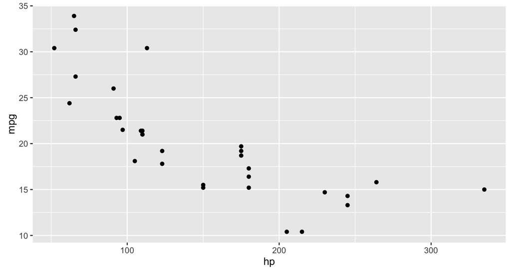

```r
ggplot(mtcars, aes(hp, mpg)) + geom_point()
```

## LaTeX

- Install a LaTeX distribution. Creates well formatted PDF versions of your presentation documents.
  - Mac: https://tug.org/mactex/
  - Windows: http://miktex.org/download
- This is a large download, so maybe do it in your spare time.

## Post-Installation

Play around with the software (especially RStudio)